# Zeisel

# Gene expression data EDA

We analyze the Zeisel dataset to familiarize ourselves with single-cell data. It comes with two matrices, a data frame containing information about the 3005 cells. The head of this file is shown below.

```
##     tissue group.. total.mRNA.mol well sex age diameter        cell_id
## 1 sscortex       1          21580   11   1  21     0.00 1772071015_C02
## 2 sscortex       1          21748   95  -1  20     9.56 1772071017_G12
## 3 sscortex       1          31642   33  -1  20    11.10 1772071017_A05
## 4 sscortex       1          32916   42   1  21    11.70 1772071014_B06
## 5 sscortex       1          21531   48   1  25    11.00 1772067065_H06
## 6 sscortex       1          24799   13  -1  20    11.90 1772071017_E02
##    level1class level2class
## 1 interneurons       Int10
## 2 interneurons       Int10
## 3 interneurons        Int6
## 4 interneurons       Int10
## 5 interneurons        Int9
## 6 interneurons        Int9
```

Specifically, under `level1class`, there are 7 classes that we are given.

```
## [1] "interneurons"         "pyramidal SS"         "pyramidal CA1"
## [4] "oligodendrocytes"     "microglia"            "endothelial-mural"
## [7] "astrocytes_ependymal"
```

The expression matrix (a matrix with 3005 cells (rows) and 19,972 genes (columns)). Each of the values in the matrix are nonnegative integers. Below is a plot of the number of instances each value appears in the matrix. The y-axis shows the log of the number of instances. We see that the vast majority of the values are numbers below 100, but there are certain values that exceed 5000.

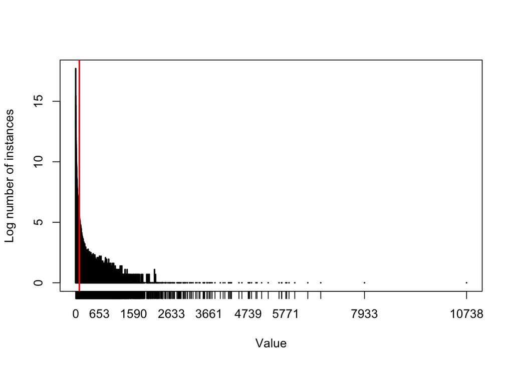

We also note that the counts for each row vary dramatically. Below we plot the empirical distribution of the total count for each row.

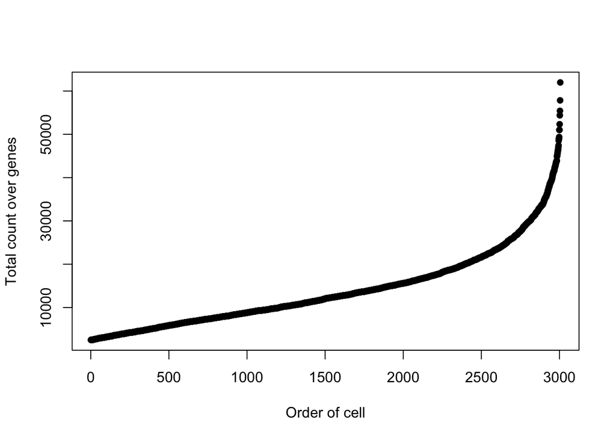

```r
plot(sort(statements[[16]]), pch = 16, xlab = "Order of cell", ylab = "Total count over genes")
```

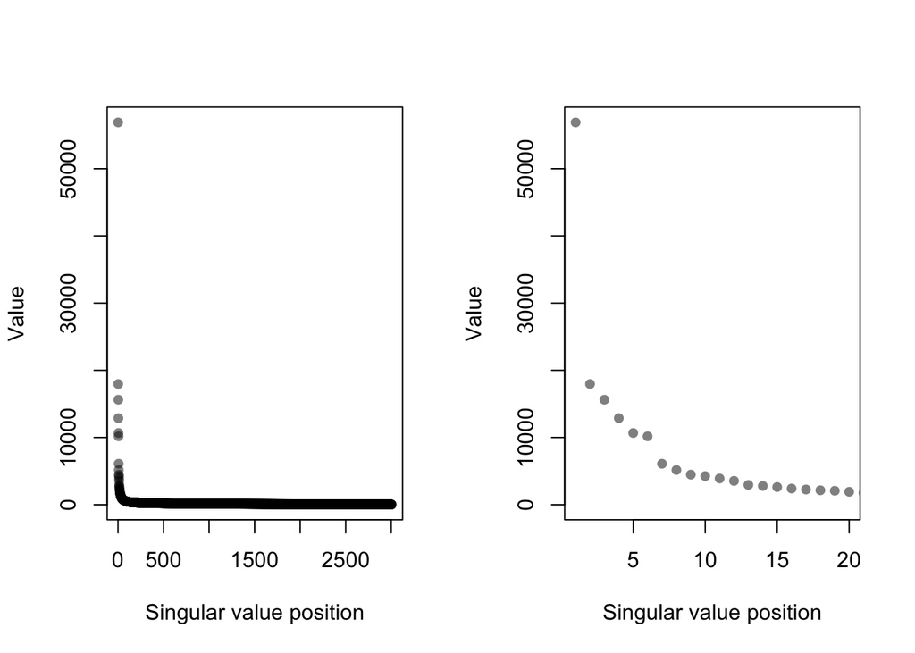

### Analysis of the cells

We can now do an EDA of the cells’ latent variables (the $U$ matrix in the SVD). This matrix is 3005 by 3005. We can plot the 3005 cells by their leading two column vectors in $U$. We see that there is no clear differentiation among the 7 cell types with exception of oligodendrocytes.

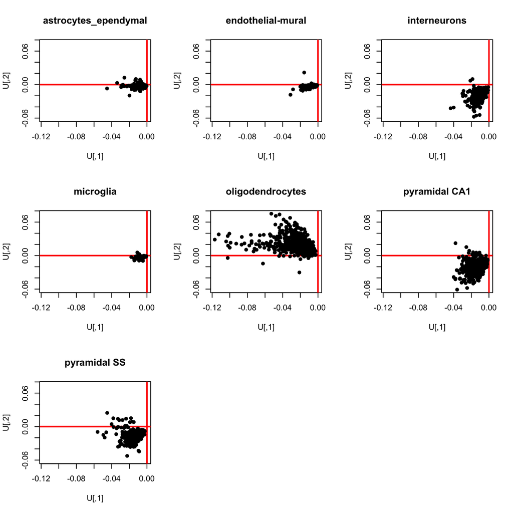

Alternatively, we can use the a nonlinear dimension reduction method (Isomap) using the leading 6 columns of $U$. The specific implementation of this is from `RDRToolbox::Isomap()`. In addition to oligodendrocytes, endothelial-mural and interneurons seem to also differentiate themselves now.

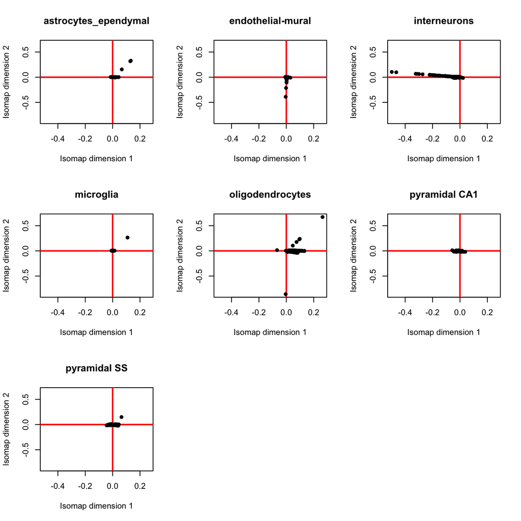

### Analysis of the genes

We now turn to analyzing the genes’ latent variables (the $V$ matrix in the SVD). We plot each of the 19,972 genes by their leading 2 column vectors in $V$. Specifically, there are two genes that dramatically distort the range of the remaining genes’ latent variables. The left plot shows the entire space, but the right plot zooms in on the bulk of the genes. The genes seem to “fan out” between two rays starting at the origin.

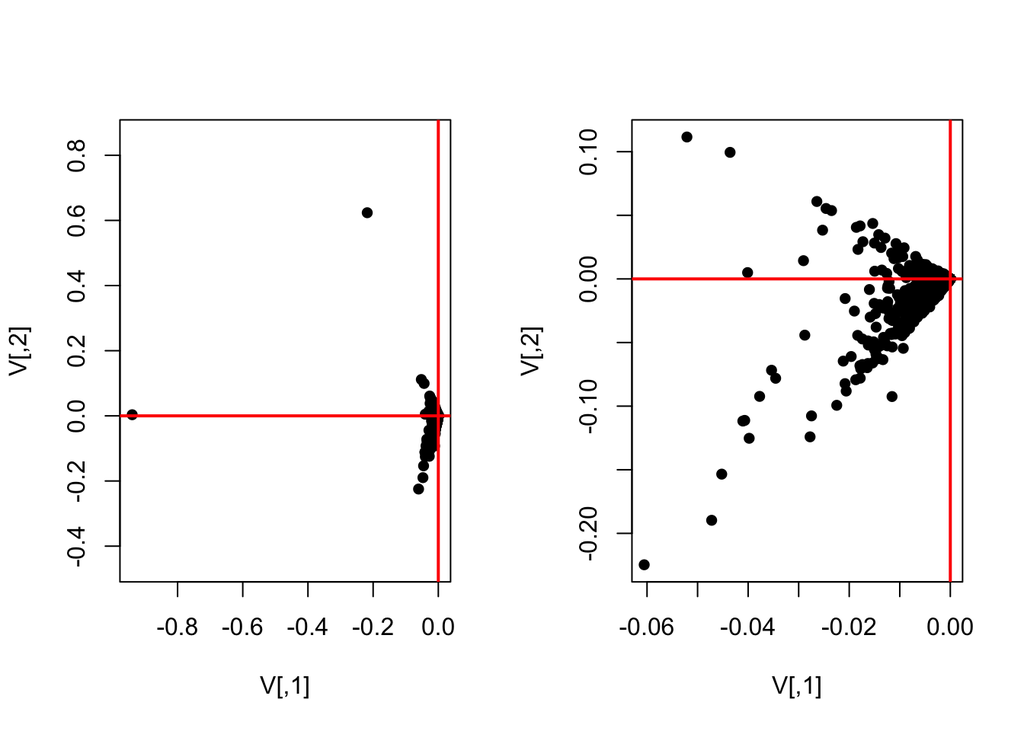

### Modeling

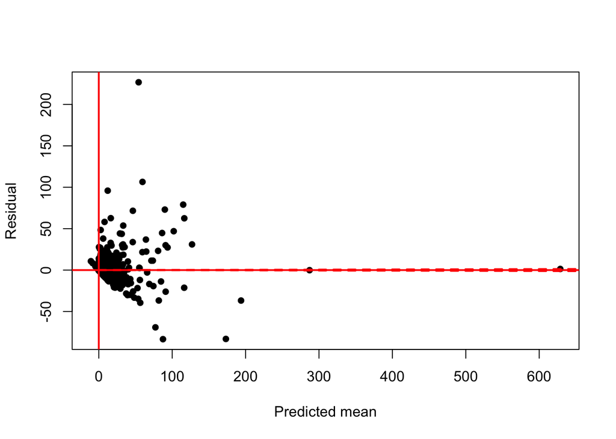

Since it seems like the Poisson model is not appropriate (i.e., the residuals for smaller predicted means are larger, and those the larger predicted means are smaller), we try taking the log of the gene expression data and re-doing the above analysis.

# Log transformation

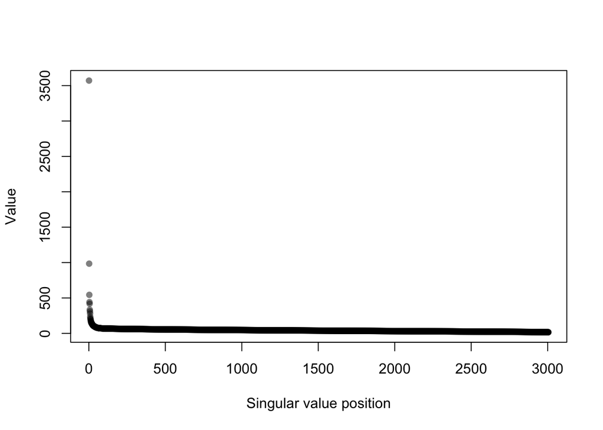

### Analysis of the cells

Like before, we can now do an EDA of the cells’ latent variables (the $U$ matrix in the SVD). We can plot the 3005 cells by their leading two column vectors in $U$. The different cell types are a bit more differeniated now, but arguably not by much compared to the previous version.

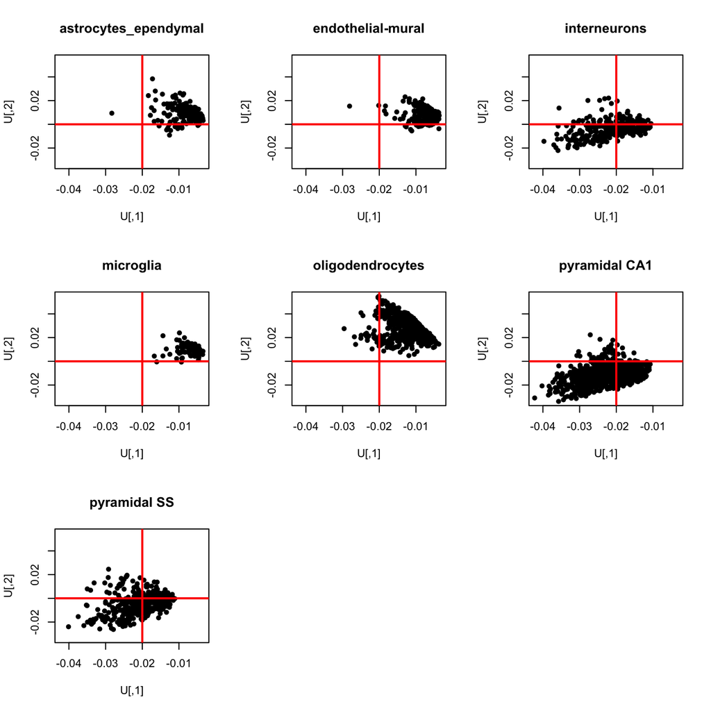

### Analysis of the genes

We now turn to analyzing the genes’ latent variables (the $V$ matrix in the SVD). We plot each of the 19,972 genes by their leading 2 column vectors in $V$. Similar to before, the genes display a “fanning-out” property.

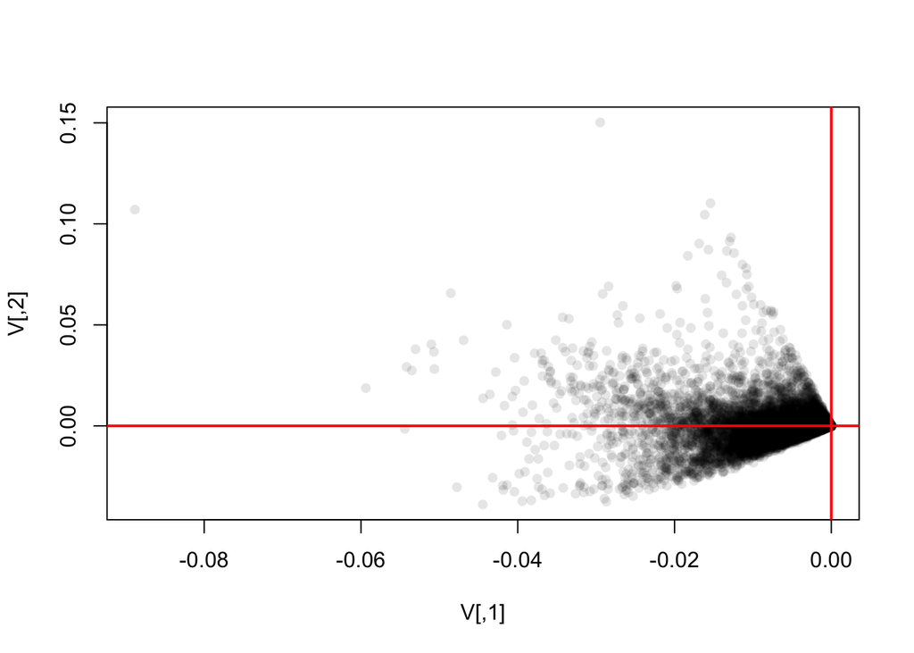

### Modeling

Similar to before, we now want to see if the model $\log(X_{ij}) \sim \text{Poisson}(U_iDV_j^T)$ is appropriate by seeing if the predicted mean and residual scale linearly. Like before, only 10,000 entries of the matrix are shown. Unfortunately, according to this diagnostic, it does not.

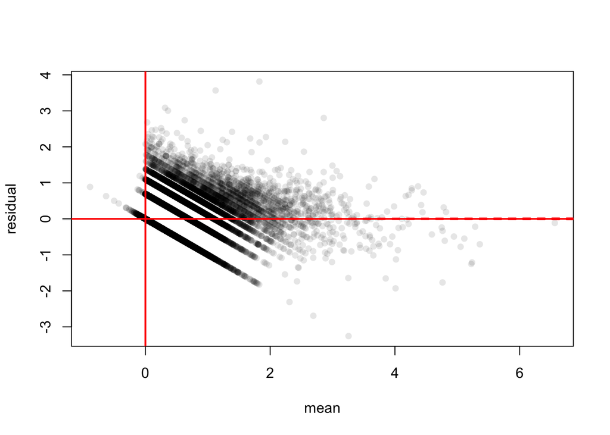

# Log transformation of selected genes

We can also to an analysis similar to those before, but only for a selected subset of genes. When plotting the singular values, we see 2 singular values that stand out.

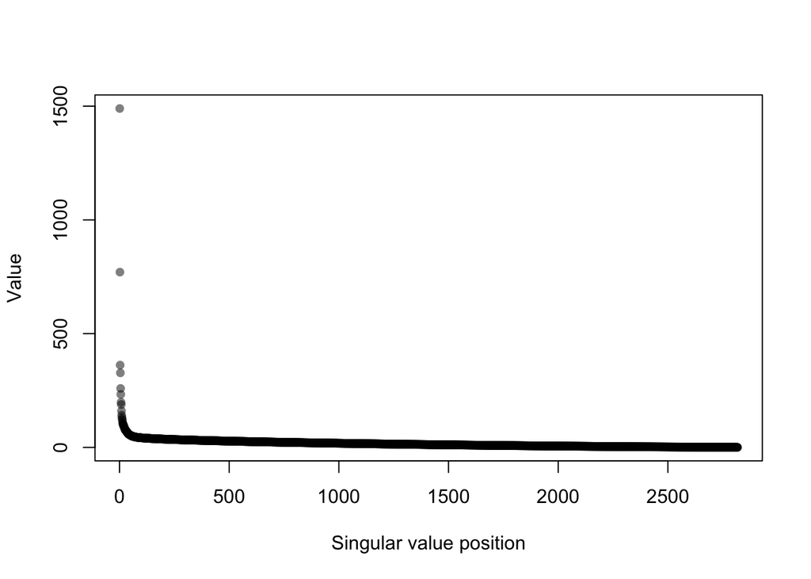

### Analysis of the cells

We can now do an EDA of the cells’ latent variables (the $U$ matrix in the SVD) like before. We start to see a more substantial differentiation between the 7 cell types.

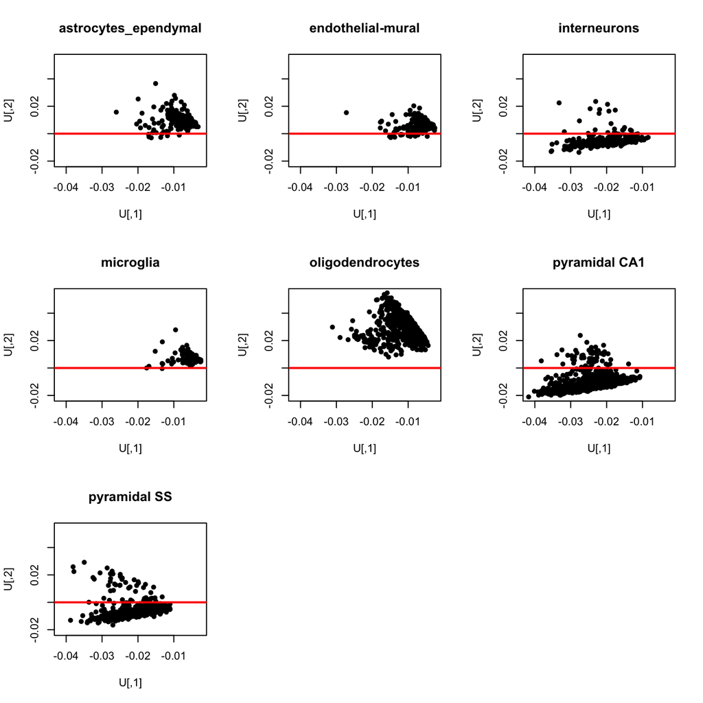

### Analysis of the genes

We now turn to analyzing the genes’ latent variables (the $V$ matrix in the SVD) like before.

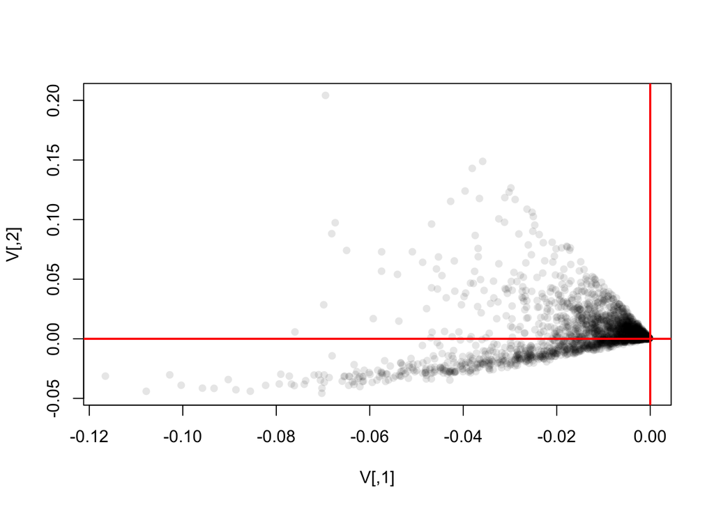

### Modeling

Similar to before, we now want to see if the model $\log(X_{ij}) \sim \text{Poisson}(U_iDV_j^T)$ is appropriate by seeing if the predicted mean and residual scale linearly. Like before, only 10,000 entries of the matrix are shown. The residuals behave strangely like before in the other log transformation analysis.

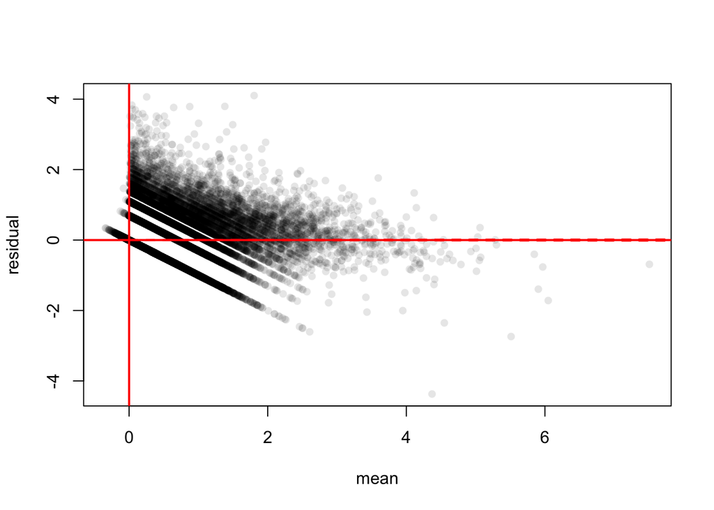